# Final_Project - Regression B

Binghan Zheng

3/29/2022

# SetUp

#Libraries

```r
library(tidyverse)
library(caret)
library(fastDummies)
```

#Preparing the Data

```r
df_all <- readr::read_csv("final_project_train.csv", col_names = TRUE)
df_all <- dummy_cols(df_all, select_columns = 'region')
df_all <- dummy_cols(df_all, select_columns = 'customer')
df_all$log_response <- log(df_all$response)
df_all
```

```
## # A tibble: 677 x 51
##    rowid region customer xb_01 xb_02 xb_03 xn_01 xn_02 xn_03 xa_01 xa_02 xa_03
##    <dbl> <chr>  <chr>    <dbl> <dbl> <dbl> <dbl> <dbl> <dbl> <dbl> <dbl> <dbl>
##  1     1 XX     B         4        4     4 3         3     3 12       12    12
##  2     3 XX     B         1        1     1 2         2     2  3        3     3
##  3     4 XX     B         2        2     2 2         4     0  9        9     9
##  4     5 XX     B         2.52    11    -6 1.53      9    -3  7.08    29    -7
##  5     8 XX     B         2.55     6    -1 0.839     3    -4  6.45    17    -2
##  6     9 XX     B         3.07     6     1 1.86      8    -2  6.86    18     2
##  7    11 XX     B         3.09    10    -4 1.51      6    -5  7.66    24    -9
##  8    14 XX     B         3.71    12    -4 1.59     10    -6  8.16    27    -5
##  9    15 XX     B         2.70     9    -2 1.17     10    -3  6.89    20    -3
## 10    16 XX     B         2.82    10    -4 1.02      4    -5  7.14    19    -3
## # ... with 667 more rows, and 39 more variables: xb_04 <dbl>, xb_05 <dbl>,
## #   xb_06 <dbl>, xb_07 <dbl>, xb_08 <dbl>, xn_04 <dbl>, xn_05 <dbl>,
## #   xn_06 <dbl>, xn_07 <dbl>, xn_08 <dbl>, xa_04 <dbl>, xa_05 <dbl>,
## #   xa_06 <dbl>, xa_07 <dbl>, xa_08 <dbl>, xw_01 <dbl>, xw_02 <dbl>,
## #   xw_03 <dbl>, xs_01 <dbl>, xs_02 <dbl>, xs_03 <dbl>, xs_04 <dbl>,
## #   xs_05 <dbl>, xs_06 <dbl>, response <dbl>, outcome <chr>, region_XX <int>,
## #   region_YY <int>, region_ZZ <int>, customer_A <int>, customer_B <int>, ...
```

##MODEL PREDICTIONS

```r
tidy_predict <- function(mod, xnew)
{
  pred_df <- predict(mod, xnew, interval = "confidence") %>%
    as.data.frame() %>% tibble::as_tibble() %>%
    dplyr::select(pred = fit, ci_lwr = lwr, ci_upr = upr) %>%
    bind_cols(predict(mod, xnew, interval = 'prediction') %>%
                as.data.frame() %>% tibble::as_tibble() %>%
                dplyr::select(pred_lwr = lwr, pred_upr = upr))

  xnew %>% bind_cols(pred_df)
}
```

```r
#For Model 6
viz_grid_6 <- expand.grid(xa_01 = median(df_all$xa_01),
                        xa_02 = median(df_all$xa_02),
                        xa_03 = median(df_all$xa_03),
                        xa_04 = median(df_all$xa_04),
                        xa_05 = median(df_all$xa_05),
                        xa_06 = median(df_all$xa_06),
                        xa_07 = median(df_all$xa_07),
                        xa_08 = median(df_all$xa_08),
                        xb_01 = median(df_all$xb_01),
                        xb_02 = median(df_all$xb_02),
                        xb_03 = median(df_all$xb_03),
                        xb_04 = median(df_all$xb_04),
                        xb_05 = seq(from = min(df_all$xb_05),
                                    to = max(df_all$xb_05),
                                    length.out = 6),
                        xb_06 = median(df_all$xb_06),
                        xb_07 = median(df_all$xb_07),
                        xb_08 = seq(from = min(df_all$xb_08),
                                    to = max(df_all$xb_08),
                                    length.out = 101),
                        xn_01 = median(df_all$xn_01),
                        xn_02 = median(df_all$xn_02),
                        xn_03 = median(df_all$xn_03),
                        xn_04 = median(df_all$xn_04),
                        xn_05 = median(df_all$xn_05),
                        xn_06 = median(df_all$xn_06),
                        xn_07 = median(df_all$xn_07),
                        xn_08 = median(df_all$xn_08),
                        xs_01 = median(df_all$xs_01),
                        xs_02 = median(df_all$xs_02),
                        xs_03 = median(df_all$xs_03),
                        xs_04 = median(df_all$xs_04),
                        xs_05 = median(df_all$xs_05),
                        xs_06 = median(df_all$xs_06),
                        xw_01 = median(df_all$xw_01),
                        xw_02 = median(df_all$xw_02),
                        xw_03 = median(df_all$xw_03),
                        KEEP.OUT.ATTRS = FALSE,
                        stringsAsFactors = FALSE) %>%
  as.data.frame() %>% tibble::as_tibble()

viz_grid_8 <- expand.grid(customer_A = median(df_all$customer_A),
                          customer_B = median(df_all$customer_B),
                          customer_D = median(df_all$customer_D),
                          customer_E = median(df_all$customer_E),
                          customer_G = median(df_all$customer_G),
                          customer_K = median(df_all$customer_K),
                          customer_M = median(df_all$customer_M),
                          customer_Other = median(df_all$customer_Other),
                          customer_Q = median(df_all$customer_Q),
                          xa_01 = median(df_all$xa_01),
                        xa_02 = median(df_all$xa_02),
                        xa_03 = median(df_all$xa_03),
                        xa_04 = median(df_all$xa_04),
                        xa_05 = median(df_all$xa_05),
                        xa_06 = median(df_all$xa_06),
                        xa_07 = median(df_all$xa_07),
                        xa_08 = median(df_all$xa_08),
                        xb_01 = median(df_all$xb_01),
                        xb_02 = median(df_all$xb_02),
                        xb_03 = median(df_all$xb_03),
                        xb_04 = median(df_all$xb_04),
                        xb_05 = seq(from = min(df_all$xb_05),
                                    to = max(df_all$xb_05),
                                    length.out = 6),
                        xb_06 = median(df_all$xb_06),
                        xb_07 = median(df_all$xb_07),
                        xb_08 = seq(from = min(df_all$xb_08),
                                    to = max(df_all$xb_08),
                                    length.out = 101),
                        xn_01 = median(df_all$xn_01),
                        xn_02 = median(df_all$xn_02),
                        xn_03 = median(df_all$xn_03),
                        xn_04 = median(df_all$xn_04),
                        xn_05 = median(df_all$xn_05),
                        xn_06 = median(df_all$xn_06),
                        xn_07 = median(df_all$xn_07),
                        xn_08 = median(df_all$xn_08),
                        xs_01 = median(df_all$xs_01),
                        xs_02 = median(df_all$xs_02),
                        xs_03 = median(df_all$xs_03),
                        xs_04 = median(df_all$xs_04),
                        xs_05 = median(df_all$xs_05),
                        xs_06 = median(df_all$xs_06),
                        xw_01 = median(df_all$xw_01),
                        xw_02 = median(df_all$xw_02),
                        xw_03 = median(df_all$xw_03),
                        KEEP.OUT.ATTRS = FALSE,
                        stringsAsFactors = FALSE) %>%
  as.data.frame() %>% tibble::as_tibble()
```

#Bayseian Model A Design Matrix - Model 6

```r
XmatA<- lm(log_response ~ (xa_01 +
              xa_02 + xa_03 + xa_04 + xa_05 + xa_06 + xa_07 + xa_08 +
              xb_01 + xb_02 +  xb_03 + xb_04 + xb_05 + xb_06 +  xb_07 + xb_08 +
              xs_01 + xs_02 + xs_03 + xs_04 + xs_05 + xs_06 +
              xn_01 + xn_02 + xn_03 + xn_04 + xn_05 + xn_06 + xn_07 + xn_08 +
              xw_01 + xw_02 + xw_03)^2 , data = df_all)
```

#Bayesian Model B Design Matrix - Model 8

```r
XmatB <- lm( log_response ~
             (splines::ns(xa_01, 2) + splines::ns(xa_02, 2) +
              splines::ns(xa_03, 2) + splines::ns(xa_04, 2) +
              splines::ns(xa_05, 2) + splines::ns(xa_06, 2) +
              splines::ns(xa_07, 2) + splines::ns(xa_08, 2) +

              splines::ns(xb_01, 2) + splines::ns(xb_02, 2) +
              splines::ns(xb_03, 2) + splines::ns(xb_04, 2) +
              splines::ns(xb_05, 2) + splines::ns(xb_06, 2) +
              splines::ns(xb_07, 2) + splines::ns(xb_08, 2) +

              splines::ns(xs_01, 2) + splines::ns(xs_02, 2) +
              splines::ns(xs_03, 2) + splines::ns(xs_04, 2) +
              splines::ns(xs_05, 2) + splines::ns(xs_06, 2) +

              splines::ns(xn_01, 2) + splines::ns(xn_02, 2) +
              splines::ns(xn_03, 2) + splines::ns(xn_04, 2) +
              splines::ns(xn_05, 2) + splines::ns(xn_06, 2) +
              splines::ns(xn_07, 2) + splines::ns(xn_08, 2) +

              splines::ns(xw_01, 2) + splines::ns(xw_02, 2) +
              splines::ns(xw_03, 2)) *

  (customer_A + customer_B + customer_D + customer_E + customer_G +
  customer_K + customer_M +  customer_Other + customer_Q),

    data = df_all)
```

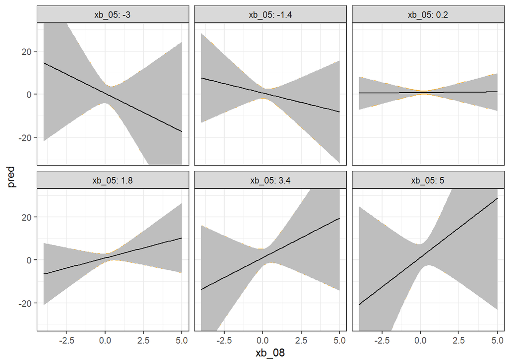

```r
predict_mod_06 <- tidy_predict(XmatA, viz_grid_6)

predict_mod_08 <- tidy_predict(XmatB, viz_grid_8)
predict_mod_06 %>%
  ggplot(mapping = aes(x = xb_08)) +
  geom_ribbon(mapping = aes(ymin = pred_lwr, ymax = pred_upr),
              fill = 'orange') +
  geom_ribbon(mapping = aes(ymin = ci_lwr, ymax = ci_upr),
              fill = 'grey') +
  geom_line(mapping = aes(y = pred),
            color = 'black') +
  coord_cartesian(ylim = c(-30, 30)) +
  facet_wrap(~xb_05, labeller = "label_both") +
  theme_bw()
```

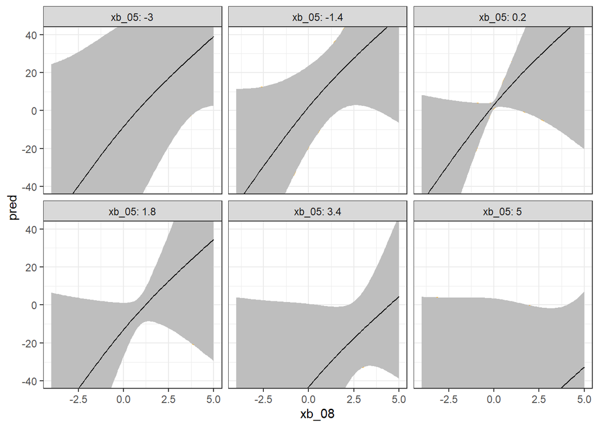

```r
predict_mod_08 %>%
  ggplot(mapping = aes(x = xb_08)) +
  geom_ribbon(mapping = aes(ymin = pred_lwr, ymax = pred_upr),
              fill = 'orange') +
  geom_ribbon(mapping = aes(ymin = ci_lwr, ymax = ci_upr),
              fill = 'grey') +
  geom_line(mapping = aes(y = pred),
            color = 'black') +
  coord_cartesian(ylim = c(-40,40)) +
  facet_wrap(~xb_05, labeller = "label_both") +
  theme_bw()
```

The predictive trends between the two selected linear models are not the same. XmatA(first graph) has a predictive mean trend which is negative for negative values of `xb_05` and a neurtral slope for the `xb_05` value which is close to 0. For positive values of `xb_05`, the slope of the predictive trend is positive and increases sharply as the value of `xb_05` increases.

The predictive trend for XmatB(second graph) has positive slopes for its trend lines regardless of the value of `xb_05` and regardless of the value of `xb_08`.

Both of these two graphs have very wide confidence intervals but prediction intervals which are tightly bound to the edges of the confidence interval. Are the predictive trends consistent between the two models?

###CLASSIFICATION

#Predictive Function

```r
my_ctrl <- trainControl(method = 'repeatedcv',
                        number = 10,
                        repeats = 3,
                        summaryFunction = twoClassSummary,
                        classProbs = TRUE,
                        savePredictions = TRUE)

ROC <- "ROC"

Accuracy <- "Accuracy"
```

#Prediction: Model A (5)

```r
mod_a_roc <- train(outcome ~
              ((xa_01 + xa_02 + xa_03 + xa_04 + xa_05 + xa_06 + xa_07 + xa_08) *
  (region_XX + region_YY + region_ZZ) +

              (xb_01 + xb_02 +  xb_03 + xb_04 + xb_05 + xb_06 +  xb_07 + xb_08) *
  (region_XX + region_YY + region_ZZ) +

              (xs_01 + xs_02 + xs_03 + xs_04 + xs_05 + xs_06)*
  (region_XX + region_YY + region_ZZ) +

              (xn_01 + xn_02 + xn_03 + xn_04 + xn_05 + xn_06 + xn_07 + xn_08)*
  (region_XX + region_YY + region_ZZ) +

              (xw_01 + xw_02 + xw_03)* (region_XX + region_YY + region_ZZ)),
             data = df_all,
                   method = "glm",
                   metric = ROC,
                   preProcess = c("center", "scale"),
                   trControl = my_ctrl)

mod_a_acc <- train(outcome ~
              (xa_01 + xa_02 + xa_03 + xa_04 + xa_05 + xa_06 + xa_07 + xa_08) *
  (region_XX + region_YY + region_ZZ) +

              (xb_01 + xb_02 +  xb_03 + xb_04 + xb_05 + xb_06 +  xb_07 + xb_08) *
  (region_XX + region_YY + region_ZZ) +

              (xs_01 + xs_02 + xs_03 + xs_04 + xs_05 + xs_06)*
  (region_XX + region_YY + region_ZZ) +

              (xn_01 + xn_02 + xn_03 + xn_04 + xn_05 + xn_06 + xn_07 + xn_08)*
  (region_XX + region_YY + region_ZZ) +

              (xw_01 + xw_02 + xw_03)*
  (region_XX + region_YY + region_ZZ),
             data = df_all,
                   method = "glm",
                   metric = Accuracy,
                   preProcess = c("center", "scale"),
                   trControl = my_ctrl)
```

#Prediction: Model B (9)

```r
mod_b_roc <- train(outcome ~

              splines::ns(xa_01, 2) + splines::ns(xa_02, 2) + splines::ns(xa_03, 2) + splines::ns(xa_04, 2) +
              splines::ns(xa_05, 2) + splines::ns(xa_06, 2) + splines::ns(xa_07, 2) + splines::ns(xa_08, 2) +

              splines::ns(xb_01, 2) + splines::ns(xb_02, 2) + splines::ns(xb_03, 2) + splines::ns(xb_04, 2) +
              splines::ns(xb_05, 2) + splines::ns(xb_06, 2) + splines::ns(xb_07, 2) + splines::ns(xb_08, 2) +

              splines::ns(xs_01, 2) + splines::ns(xs_02, 2) + splines::ns(xs_03, 2) + splines::ns(xs_04, 2) +
              splines::ns(xs_05, 2) + splines::ns(xs_06, 2) +

              splines::ns(xn_01, 2) + splines::ns(xn_02, 2) + splines::ns(xn_03, 2) + splines::ns(xn_04, 2) +
              splines::ns(xn_05, 2) + splines::ns(xn_06, 2) + splines::ns(xn_07, 2) + splines::ns(xn_08, 2) +

              splines::ns(xw_01, 2) + splines::ns(xw_02, 2) + splines::ns(xw_03, 2),

             data = df_all,
                   method = "glm",
                   metric = ROC,
                   preProcess = c("center", "scale"),
                   trControl = my_ctrl)

mod_b_acc <- train(outcome ~

              splines::ns(xa_01, 2) + splines::ns(xa_02, 2) + splines::ns(xa_03, 2) + splines::ns(xa_04, 2) +
              splines::ns(xa_05, 2) + splines::ns(xa_06, 2) + splines::ns(xa_07, 2) + splines::ns(xa_08, 2) +

              splines::ns(xb_01, 2) + splines::ns(xb_02, 2) + splines::ns(xb_03, 2) + splines::ns(xb_04, 2) +
              splines::ns(xb_05, 2) + splines::ns(xb_06, 2) + splines::ns(xb_07, 2) + splines::ns(xb_08, 2) +

              splines::ns(xs_01, 2) + splines::ns(xs_02, 2) + splines::ns(xs_03, 2) + splines::ns(xs_04, 2) +
              splines::ns(xs_05, 2) + splines::ns(xs_06, 2) +

              splines::ns(xn_01, 2) + splines::ns(xn_02, 2) + splines::ns(xn_03, 2) + splines::ns(xn_04, 2) +
              splines::ns(xn_05, 2) + splines::ns(xn_06, 2) + splines::ns(xn_07, 2) + splines::ns(xn_08, 2) +

              splines::ns(xw_01, 2) + splines::ns(xw_02, 2) + splines::ns(xw_03, 2),

             data = df_all,
                   method = "glm",
                   metric = Accuracy,
                   preProcess = c("center", "scale"),
                   trControl = my_ctrl)
```

#Visualization: Model A

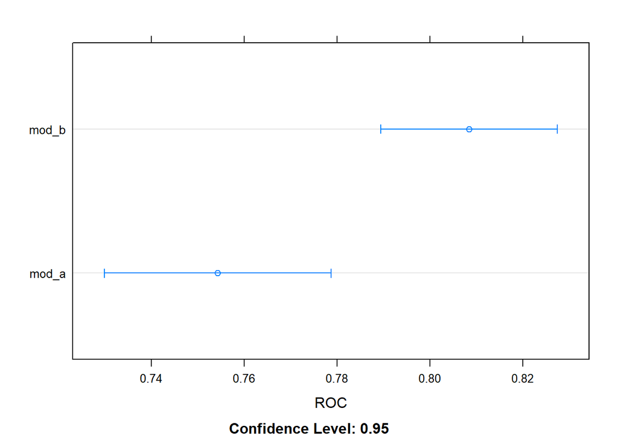

```r
#must include mean event probability, confidence interval
roc_results <- resamples(list(mod_a = mod_a_roc,
                              mod_b = mod_b_roc))
dotplot(roc_results, metric="ROC")
```

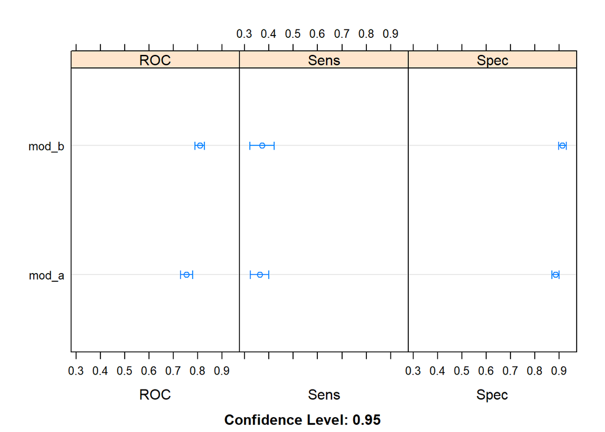

```r
dotplot(roc_results)
```

```r
acc_results <- resamples(list(mod_a = mod_a_acc,
                              mod_b = mod_b_acc))
#dotplot(acc_results, metric="Accuracy")
#dotplot(acc_results)

mod_a_roc$pred %>% tibble::as_tibble()
```

```
## # A tibble: 2,031 x 7
##    pred      obs          event non_event rowIndex parameter Resample
##    <fct>     <fct>        <dbl>     <dbl>    <int> <chr>     <chr>
##  1 non_event non_event 0.00658     0.993         1 none      Fold01.Rep1
##  2 event     non_event 0.731       0.269         7 none      Fold01.Rep1
##  3 non_event non_event 0.304       0.696        14 none      Fold01.Rep1
##  4 non_event non_event 0.267       0.733        16 none      Fold01.Rep1
##  5 non_event non_event 0.377       0.623        23 none      Fold01.Rep1
##  6 event     non_event 0.968       0.0320       56 none      Fold01.Rep1
##  7 non_event non_event 0.0386      0.961        57 none      Fold01.Rep1
##  8 non_event non_event 0.0586      0.941        69 none      Fold01.Rep1
##  9 non_event non_event 0.00324     0.997        73 none      Fold01.Rep1
## 10 non_event non_event 0.000610    0.999       114 none      Fold01.Rep1
## # ... with 2,021 more rows
```

```r
mod_a_roc$pred %>% yardstick::roc_curve(obs, event)
```

```
## # A tibble: 2,032 x 3
##     .threshold specificity sensitivity
##          <dbl>       <dbl>       <dbl>
##  1 -Inf           0              1
##  2    3.67e-12    0              1
##  3    2.40e-10    0.000606       1
##  4    2.86e-10    0.00121        1
##  5    3.61e-10    0.00182        1
##  6    1.54e- 9    0.00242        1
##  7    1.86e- 9    0.00303        1
##  8    3.73e- 9    0.00364        1
##  9    4.13e- 9    0.00364        0.997
## 10    4.19e- 9    0.00424        0.997
## # ... with 2,022 more rows
```

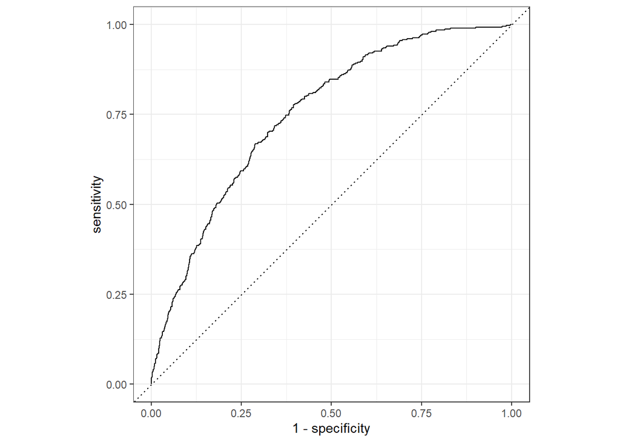

```r
mod_a_roc$pred %>% yardstick::roc_curve(obs, event) %>% autoplot()
```

#Visualization: Model B

```r
mod_b_roc$pred %>% tibble::as_tibble()
```

```
## # A tibble: 2,031 x 7
##    pred      obs              event non_event rowIndex parameter Resample
##    <fct>     <fct>            <dbl>     <dbl>    <int> <chr>     <chr>
##  1 non_event non_event 0.196            0.804        5 none      Fold01.Rep1
##  2 non_event non_event 0.0938           0.906       14 none      Fold01.Rep1
##  3 non_event non_event 0.00000217       1.00        32 none      Fold01.Rep1
##  4 non_event non_event 0.0222           0.978       58 none      Fold01.Rep1
##  5 non_event non_event 0.0243           0.976       68 none      Fold01.Rep1
##  6 non_event non_event 0.00962          0.990       74 none      Fold01.Rep1
##  7 non_event non_event 0.00415          0.996       91 none      Fold01.Rep1
##  8 non_event non_event 0.0264           0.974      100 none      Fold01.Rep1
##  9 non_event non_event 0.0000000635     1.00       119 none      Fold01.Rep1
## 10 event     event     0.596            0.404      120 none      Fold01.Rep1
## # ... with 2,021 more rows
```

```r
mod_b_roc$pred %>% yardstick::roc_curve(obs, event)
```

```
## # A tibble: 2,029 x 3
##     .threshold specificity sensitivity
##          <dbl>       <dbl>       <dbl>
##  1 -Inf            0                 1
##  2    2.22e-16     0                 1
##  3    1.41e-13     0.00303           1
##  4    4.24e-13     0.00364           1
##  5    1.08e-12     0.00424           1
##  6    2.33e-12     0.00485           1
##  7    6.27e-12     0.00545           1
##  8    6.96e-12     0.00606           1
##  9    9.07e-12     0.00667           1
## 10    1.26e-11     0.00727           1
## # ... with 2,019 more rows
```

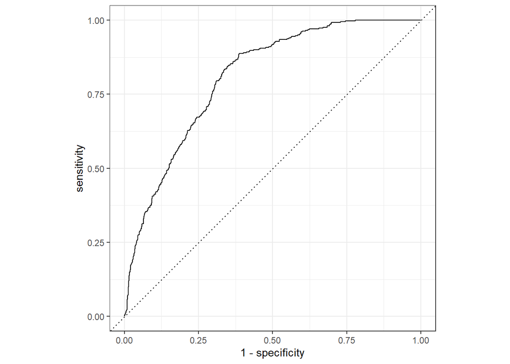

```r
mod_b_roc$pred %>% yardstick::roc_curve(obs, event) %>% autoplot()
```

```r
prob <- predict(mod_a_roc, df_all, type = "prob")$event
```

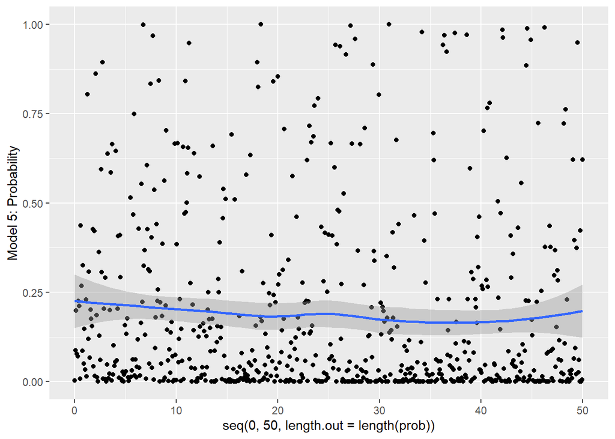

```r
ggplot(mapping = aes(x = seq(0, 50, length.out = length(prob)), y = prob)) +
  geom_point() +
  geom_smooth() +
  ylab("Model 5: Probability")
```

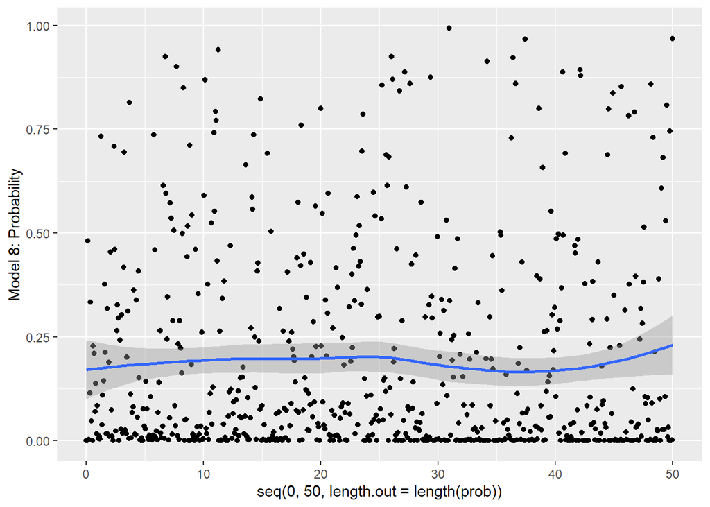

```r
prob <- predict(mod_b_roc, df_all, type = "prob")$event

ggplot(mapping = aes(x = seq(0, 50, length.out = length(prob)), y = prob)) +
  geom_point() +
  geom_smooth() +
  ylab("Model 8: Probability")
```

Are the predictive trends consistent between the two models?

Yes, they are consistent